# Extracellular Electrophysiology

Session 1

OSSS Ephys Course 2026

## The instructor team

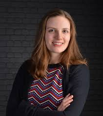

Enny van Beest

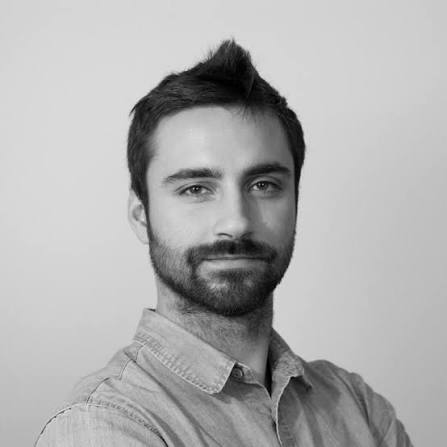

Alessio Buccino

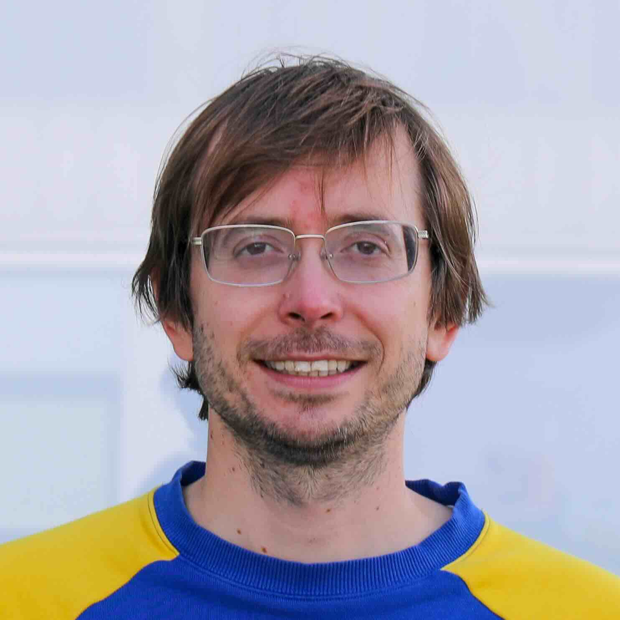

Chris Halcrow

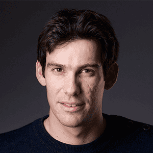

Olivier Winter

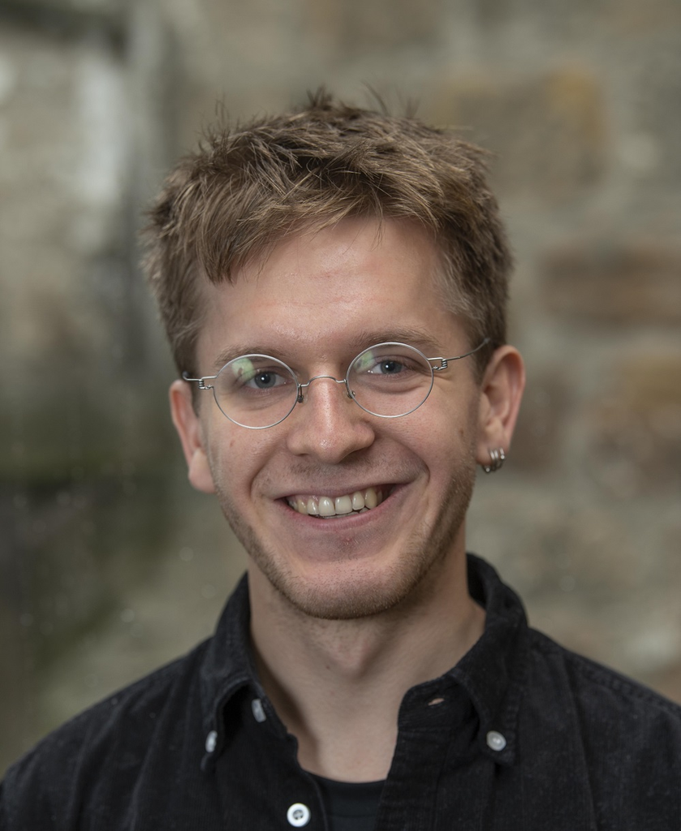

Wolf De Wulf

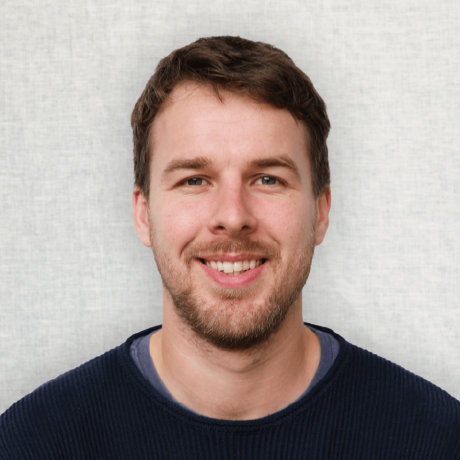

Joe Ziminski

## Backgrounds

**What is your research / academic background?**

menti.com/?code=67083044

## Research interests

**What is your current research interest?**

menti.com/?code=67083044

## Today’s session

1. Course Introduction
2. Introduction to extracellular electrophysiology
3. Coding a full pipeline with SpikeInterface

## Course objectives

- Gain hands-on experience implementing an extracellular electrophysiology pipeline
- Introduce the underlying theory of the processing steps
- Have fun! meet people, collaborate, and discuss your own data

## Timeline

| Session | When |
| --- | --- |
| **Session 1: Introduction** | Monday, 10:00-13:00 |
| **Session 2: Data quality and preprocessing** | Tuesday, 10:00-13:00 |
| **Session 3: Sorting and UnitMatch** | Tuesday, 14:00-17:00 |
| **Session 4: Postprocessing and Curation** | Wednesday, 10:00-13:00 |
| **Session 5: Analysis (Pynapple and Probe-anatomy alignment)** | Wednesday, 14:00-17:00 |

## Course book

- We will work through the course book available at:  
  [neuroinformatics.dev/course_ephys_osss](https://neuroinformatics.dev/course_ephys_osss/)
- Feel free to open this link now (these slides are Chapter 2).
- We will work through Chapter 3 today.

## Your own data

- We welcome you trying out the methods discussed on your own data
- Please feel free to ask questions related to your own data at any point
- If you are already familiar with the concepts covered in exercises, feel free to apply the methods discussed on your own data

## Own data?

**Do you have your own data?**

menti.com/?code=67083044

## Coding sections

- We will go through core sections together, with time for exercises and free coding
- Writing code by hand improves understanding
  - (avoid using LLMs)
- This is particularly true for debugging - if stuck, ask your neighbor or a TA!

So each of these breakthroughs, they are the culmination of, and couldn’t exist without, the many months of stumbling around in the dark that precede them.

**Andrew Wiles**, solved Fermat’s Last Theorem

Focusing on important questions puts us in the awkward position of being ignorant. One of the beautiful things about science is that it allows us to bumble along, getting it wrong time after time, and feel perfectly fine as long as we learn something each time.

[**Martin Schwartz**](https://journals.biologists.com/jcs/article/121/11/1771/30038/The-importance-of-stupidity-in-scientific-research), professor of cell biology

If I spend an entire day and all I do is understand this one feature of this one object that I didn’t understand before, then that’s a great day.

**PhD student**

Being comfortable  
in confusion

My advisor once told me that doing science is 98% being confused and 2% figuring it out.

**PhD student**

When you allow yourself to be confused you become far more introspective; you gain the clarity you desire by questioning and reconciling a variety of ideas and alternatives that may feel overwhelming.

[**Peter Winick**](https://thoughtleadershipleverage.com/embracing-confusion/), CEO of *Thought Leadership*

## Introduction to extracellular electrophysiology

## Method overview

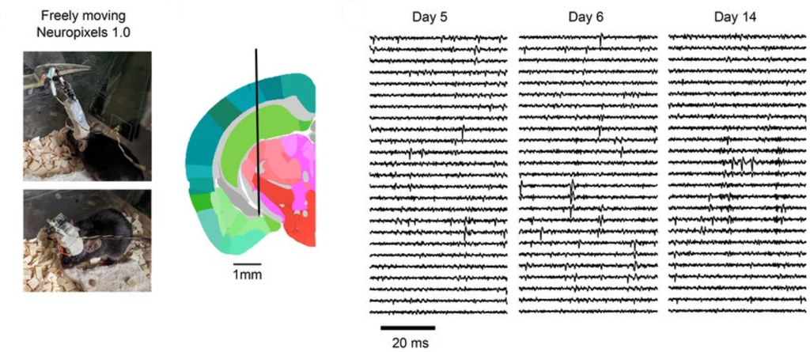

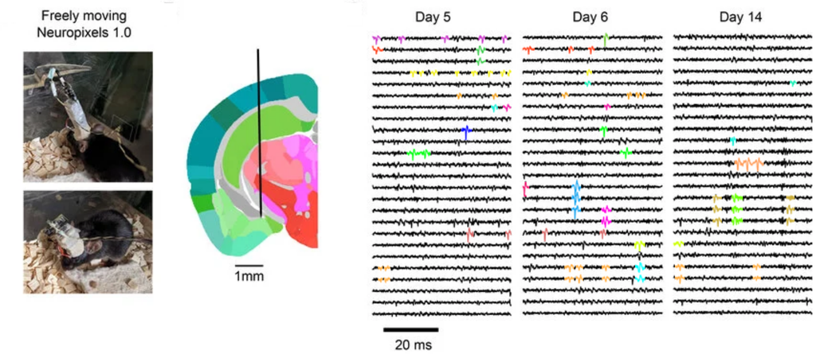

**1.** Implant recording electrode

**2.** Record during behavior of interest

**3.** Identify action potentials in the recorded trace

**4.** Assign action potentials to neurons with spike sorting

**5.** Understand how neural activity encodes behavior

## Classic findings

### Orientation selectivity (Hubel and Wiesel, 1962)

[video not shown]

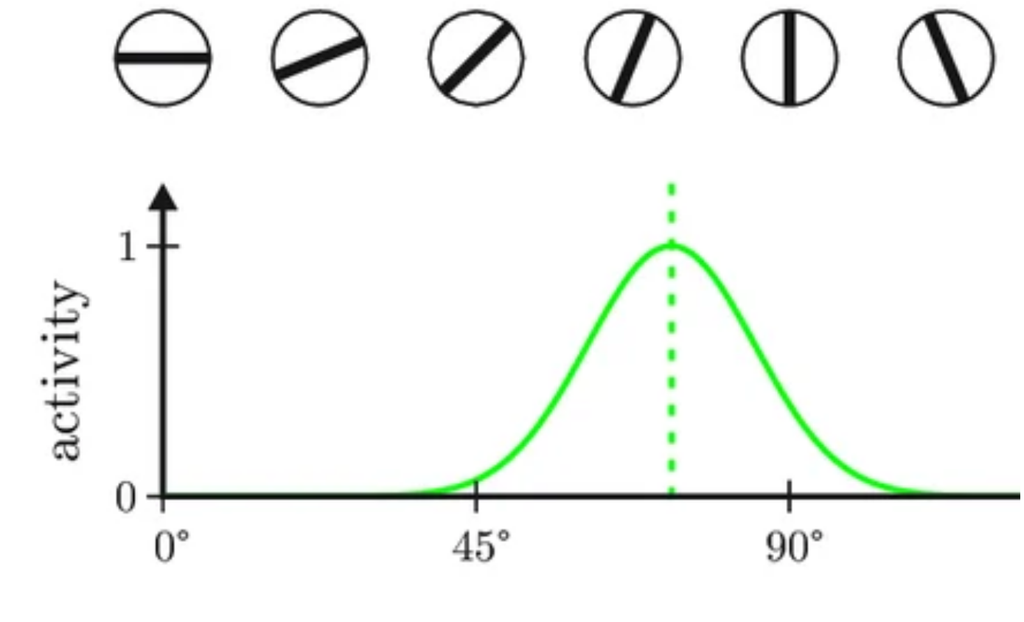

### Hippocampal space encoding

[video not shown]

## In the clinic

[video not shown]

## Evolution of recording devices

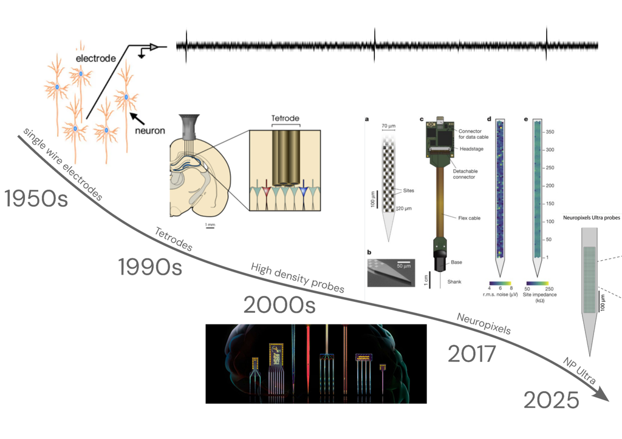

## Extracellular electrophysiological data

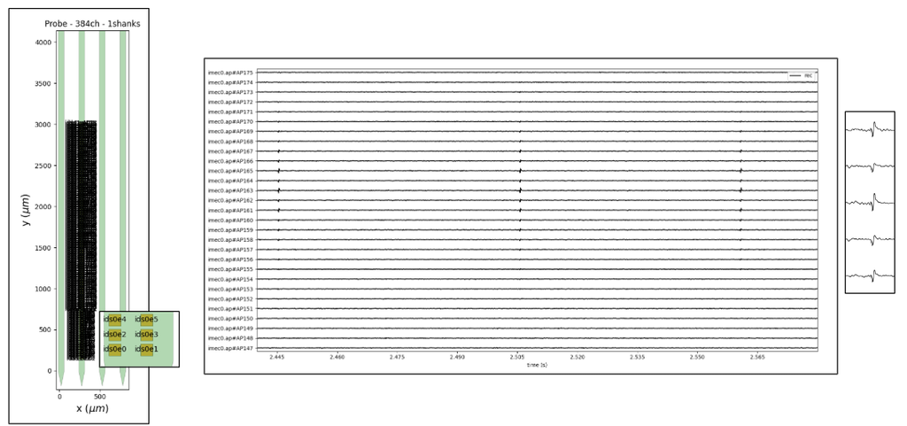

## Extracellular electrophysiological data

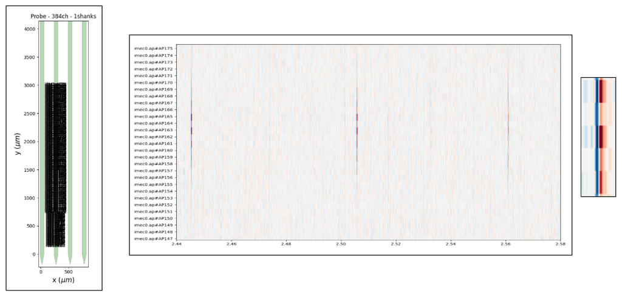

## The action potential

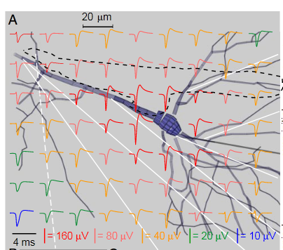

From [Gold et al. (2006)](https://pubmed.ncbi.nlm.nih.gov/16467426/)

## The recording setup

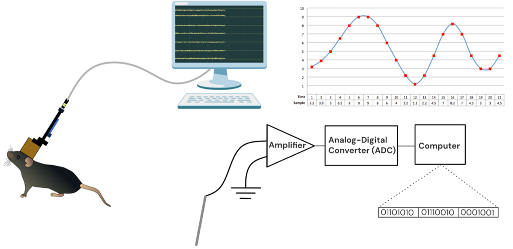

## Preprocessing

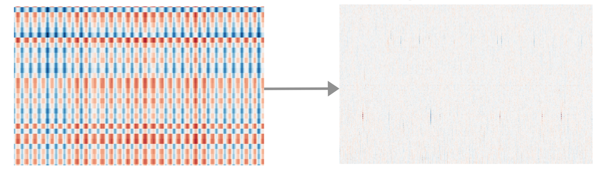

### Sorting

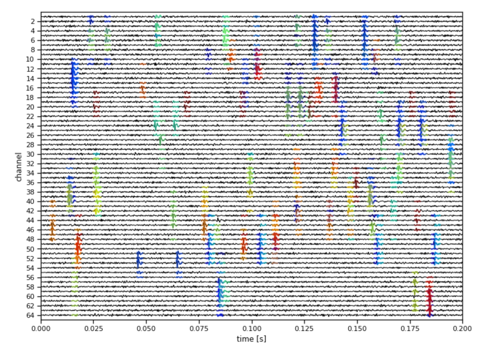

### UnitMatching

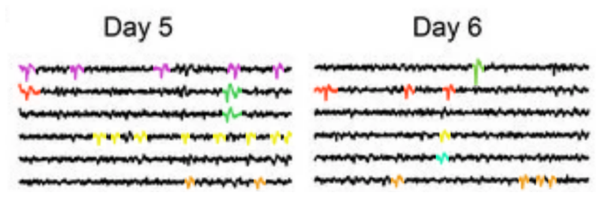

## Postprocessing

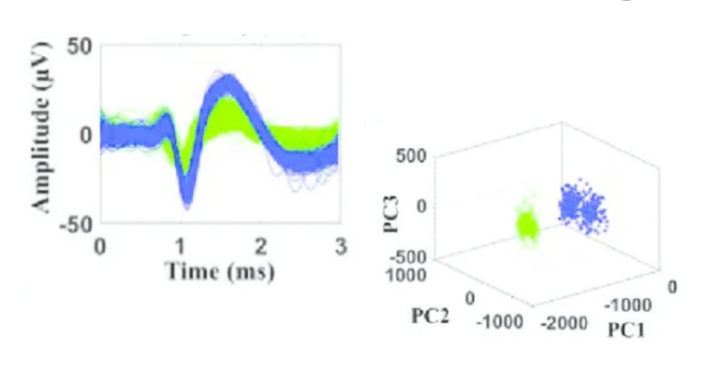

## Analysis

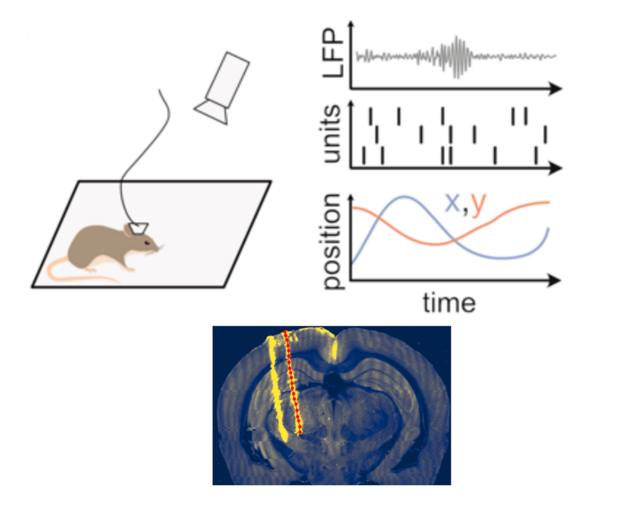

## SpikeInterface

A common API for open-source electrophysiological tools

[figure not shown]

## Building a pipeline in Python

## Course setup

- The setup instructions are on the ‘Python setup’ page of the course handbook:

[neuroinformatics.dev/course_ephys_osss/setup](https://neuroinformatics.dev/course_ephys_osss/setup.html)

- We will go through it together now
- ✅ uv environment linked to IDE

## Downloading data for the course

Download everything you need for the course from:

- The [course Zenodo repository](https://zenodo.org/records/21908762) — all core datasets.
  - ✅ `sub-001_ses-001_g0_t0.imec0.ap.bin`
  - ✅ `sub-001_ses-001_g0_t0.imec0.ap.meta`
- The **AL032** dataset from [Dropbox](https://www.dropbox.com/scl/fo/1019utuiqbogkyxeqpm8a/AKov2FuY5XZfx5JjIEVuoO4?rlkey=1xcxyki0ijktmxz1k62qg07hh&st=4rrisszb&e=1&dl=0) — UnitMatch chapter.
- *(optional)* The larger **EB055** dataset from the same Dropbox — UnitMatch extended exercises.

## Python imports

```python
from pathlib import Path
import matplotlib.pyplot as plt
import spikeinterface.full as si
from probeinterface.plotting import plot_probe
from spikeinterface_gui import run_mainwindow

print("Finished importing")
```

## Feedback

[Day 1 feedback board](https://ideaboardz.com/for/Extracellular%20Electrophysiology%20-%20Day%201/5814935)

## Appendix

## Data checks

```
SpikeGLXRecordingExtractor: 384 channels - 30.0kHz - 1 segments - 75,000 samples - 2.50s
                            int16 dtype - 54.93 MiB
```

Each sample is stored as a 16-bit integer (`int16`) — that is 2 bytes:

[figure not shown]

## Pros and cons

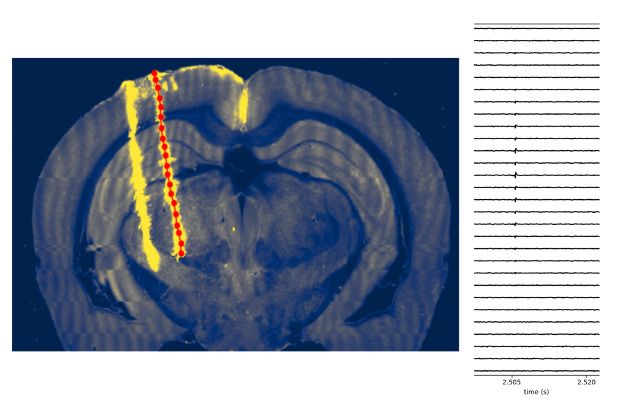

### Electrophysiology

- ✅ High temporal resolution
- ✅ Targeted to deep and multiple regions
- ❌ Cannot easily identify individual neurons

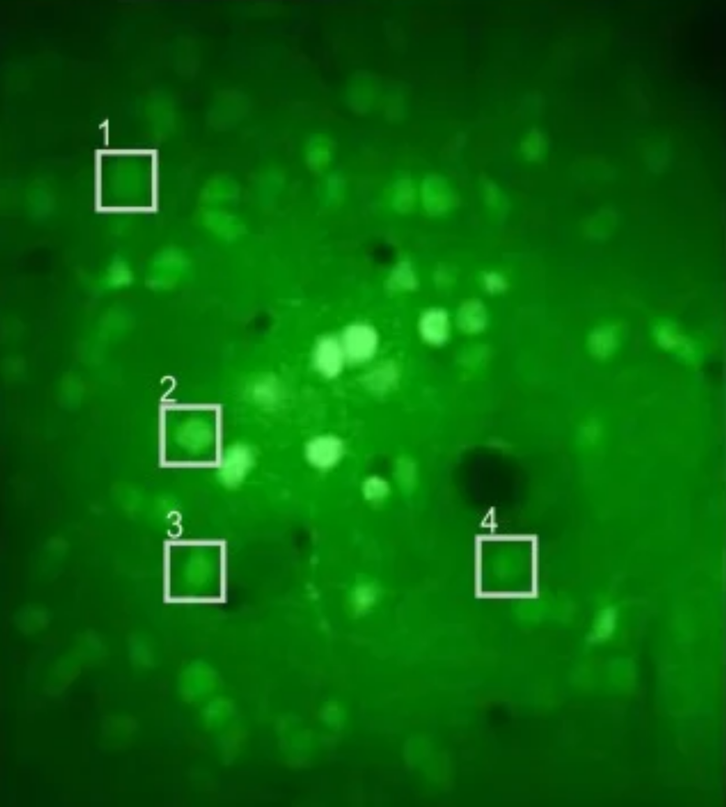

### Imaging

- ✅ Easy identification of individual neurons (genetically targetable)
- ❌ Low temporal resolution
- ❌ Limited depth and field of view